# Project (Assignment 9)

```python
# Best features

k=2
best_feats= {}
X_best_feats= {}


for i, index in enumerate(C):

    # create a handle to the feature selector
    selector = SelectKBest(f_regression,k=k)

    # fit to our sample data
    selector.fit(X[i], y[i])

    # computes the best features (2 of them, because K=2)
    best_feats = selector.get_support(indices=True)
    best_feats

    # select the two columns corresponding to the best features
    X_best_feats[i] = X[i].iloc[:,best_feats]

    # show the best 2 features computed so far
    print(X_best_feats[i].head())
```

```
Indicator        ind        ser
21         31.512623  48.846332
22         33.987598  47.055692
23         36.125680  44.130457
24         34.666943  43.458398
25         23.381460  58.121416
Indicator        agr           pop
71         24.034067  1.150780e+09
72         21.328861  1.164970e+09
73         19.307468  1.178440e+09
74         19.474283  1.191835e+09
75         19.596520  1.204855e+09
Indicator       for_inv     gdp_cap
121        7.353764e+07  303.055605
122        2.765124e+08  316.953928
123        5.503700e+08  301.159004
124        9.732715e+08  346.102950
125        2.143628e+09  373.766480
Indicator      gdp_cap  lab_for_15_64
171        3490.452505      75.828003
172        3098.802639      75.857002
173        2930.670201      74.056999
174        2662.104034      71.964996
175        2665.779867      71.388000
Indicator  employers      gdp_cap
221            7.506  3285.954650
222            7.524  3479.066283
223            7.536  3388.729303
224            7.542  3445.230068
225            7.548  3751.854328
```

**Regression analysis**

1. Partition the data in training and testing.

In this model, we will use k-fold cross-validation method. In k-fold cross-validation, the original sample is randomly partitioned into k equal sized subsamples. Of the k subsamples, a single subsample is retained as the validation data for testing the model, and the remaining k − 1 subsamples are used as training data. The cross-validation process is then repeated k times, with each of the k subsamples used exactly once as the validation data.

1. Train the models, using regression (linear and polynomial, of an appropriate degree). Test the regression models using the testing set.
2. The mean sqaured error will be used as a metric to evaluate the performance of the models.

```python
def PolynomialRegression(degree=2, **kwargs):
        return make_pipeline(PolynomialFeatures(degree), LinearRegression(**kwargs))

def RegressionAndResults (X_best_feats, df, country, df_fields, range_cv=1):


        dfx = df[X_best_feats.columns] # for the regression we will use the database without the handling nan
                                       # to avoid misinterpretation

        X=[0,0]
        Y=[0,0]

        i=0
        for col in dfx.columns:
            X[i] = df[[col]][df[col].notnull()] # we will disregard the values for X and Y when X is nan
            Y[i] = df[['unemp']][df[col].notnull()]
            i=i+1

        param_grid = {'polynomialfeatures__degree': np.arange(21),
                      'linearregression__fit_intercept': [True, False],
                      'linearregression__normalize': [True, False]}

        degree = [0,0]
        model = [0,0]
        score = [-1000,-1000]
        cross_validation = [0,0]

        # Others: results = {}, param = {}, index = {}

        for i, index in enumerate(dfx):

            l= len(X[i]) # Define the number max of cross validation according to the len of data

            if range_cv==1:
                range_cv = (2, l)

            for cv in range_cv:
                grid = GridSearchCV(PolynomialRegression(), param_grid, cv=cv, scoring= 'neg_mean_squared_error', verbose = 0)
                # using grid search to find the optimal polynomial model
                grid.fit(X[i], Y[i])

                if grid.best_score_> score[i]:
                    cross_validation [i] = cv
                    degree [i] = grid.best_params_['polynomialfeatures__degree']
                    score [i] = grid.best_score_
                    model [i] = grid.best_estimator_
                    # Others: results [i] = grid.cv_results_['mean_test_score'], param [i]= grid.best_params_,
                    # index [i] = grid.best_index_

            print ("Country:", country, "\n")
            print ('Regression', X[i].columns.values)
            print ("Best score:", score[i], "Cross validation",  cross_validation [i])
            print ("Degree:", degree[i])
            print ("Model:", model[i])
            print ("--------------------------")

        for i, ind in enumerate(dfx):

            x_train,x_test,y_train,y_test=train_test_split(X[i],Y[i],test_size=0.50,random_state=1)
            y_test = model[i].fit(x_train, y_train).predict(x_test)


            plt.scatter(X[i], Y[i], color='blue', label = 'original')
            plt.scatter(x_test,y_test, color='gray', label = 'degree '+ str(degree[i]))
            plt.title('Polinomial Regression' + '- degree '+ str(degree[i])+ '- '+ str(X[i].columns[0]))
            plt.xlabel(df_fields.loc[((X[i]).columns[0])]['Series']+df_fields.loc[((X[i]).columns[0])]['Unit'])
            plt.ylabel(df_fields.loc[((Y[i]).columns[0])]['Series']+df_fields.loc[((Y[i]).columns[0])]['Unit'])
            plt.legend()
            plt.show()
```

```
Country: BRA

Regression ['ind']
Best score: -1.4058416931312818 Cross validation 29
Degree: 7
Model: Pipeline(steps=[('polynomialfeatures', PolynomialFeatures(degree=7)),
                ('linearregression',
                 LinearRegression(fit_intercept=False, normalize=True))])
--------------------------
Country: BRA

Regression ['ser']
Best score: -1.3503898258407092 Cross validation 29
Degree: 5
Model: Pipeline(steps=[('polynomialfeatures', PolynomialFeatures(degree=5)),
                ('linearregression', LinearRegression())])
--------------------------
```

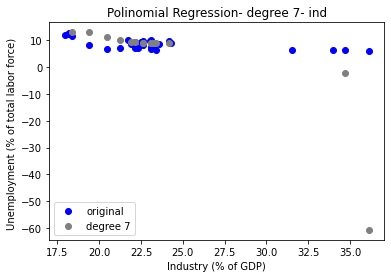

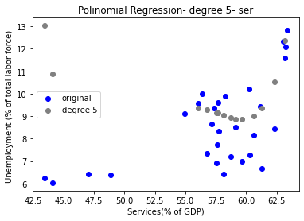

```python
RegressionAndResults (X_best_feats[0], df_c[0], C[0], df_fields, 1)
```

```
Country: BRA

Regression ['ser']
Best score: -1.6108313166377428 Cross validation 20
Degree: 18
Model: Pipeline(steps=[('polynomialfeatures', PolynomialFeatures(degree=18)),
                ('linearregression', LinearRegression())])
--------------------------
```

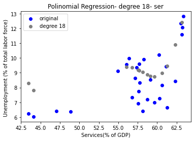

```python
# Sensitivity of k - 2nd regression
RegressionAndResults (df_c[0][['ser']], df_c[0], C[0], df_fields, (5,10,15,20))
```

```
Country: CHN

Regression ['agr']
Best score: -0.048533741215625675 Cross validation 29
Degree: 3
Model: Pipeline(steps=[('polynomialfeatures', PolynomialFeatures(degree=3)),
                ('linearregression', LinearRegression())])
--------------------------
Country: CHN

Regression ['pop']
Best score: -0.03702186312327986 Cross validation 29
Degree: 7
Model: Pipeline(steps=[('polynomialfeatures', PolynomialFeatures(degree=7)),
                ('linearregression', LinearRegression(normalize=True))])
--------------------------
```

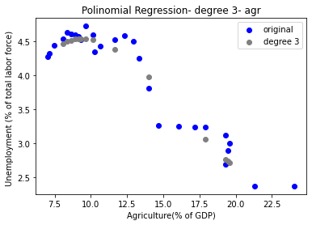

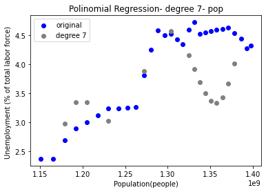

```python
# RegressionAndResults (X_best_feats[1], df_c[1], C[1], df_fields, 1)
```

```
Country: CHN

Regression ['emp_sal_work']
Best score: -0.022996599250121878 Cross validation 29
Degree: 9
Model: Pipeline(steps=[('polynomialfeatures', PolynomialFeatures(degree=9)),
                ('linearregression', LinearRegression(normalize=True))])
--------------------------
```

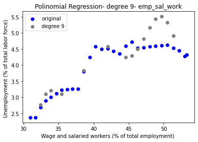

```python
# Verifying the correlation between unemployment and waged and salaried workers
RegressionAndResults (df[df['country']=='CHN'][['emp_sal_work']], df[df['country']=='CHN'], C[1], df_fields, 1)
```

```
Country: IND

Regression ['for_inv']
Best score: -0.011081105709219743 Cross validation 28
Degree: 5
Model: Pipeline(steps=[('polynomialfeatures', PolynomialFeatures(degree=5)),
                ('linearregression', LinearRegression())])
--------------------------
Country: IND

Regression ['gdp_cap']
Best score: -0.006313587795909836 Cross validation 27
Degree: 5
Model: Pipeline(steps=[('polynomialfeatures', PolynomialFeatures(degree=5)),
                ('linearregression', LinearRegression(normalize=True))])
--------------------------
```

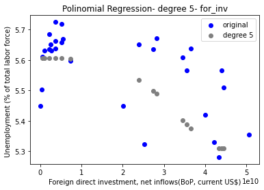

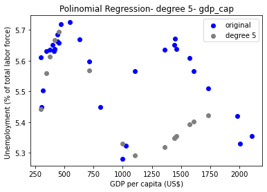

```python
# RegressionAndResults (X_best_feats[2], df_c[2], C[2], df_fields, 1)
```

```
Country: IND

Regression ['exp_edu']
Best score: -0.005119677509334082 Cross validation 10
Degree: 1
Model: Pipeline(steps=[('polynomialfeatures', PolynomialFeatures(degree=1)),
                ('linearregression', LinearRegression(normalize=True))])
--------------------------
```

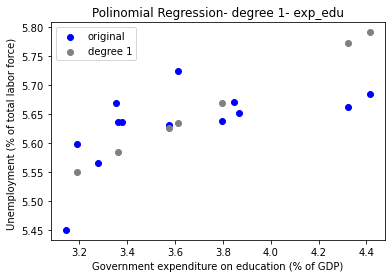

```python
# RegressionAndResults (df_reg[df_reg['country']=='IND'][['exp_edu']], df_reg[df_reg['country']=='IND'], C[2], df_fields, (10,10))
```

```
Country: RUS

Regression ['gdp_cap']
Best score: -2.334750796314984 Cross validation 29
Degree: 5
Model: Pipeline(steps=[('polynomialfeatures', PolynomialFeatures(degree=5)),
                ('linearregression', LinearRegression(normalize=True))])
--------------------------
Country: RUS

Regression ['lab_for_15_64']
Best score: -1.4753769114544986 Cross validation 29
Degree: 11
Model: Pipeline(steps=[('polynomialfeatures', PolynomialFeatures(degree=11)),
                ('linearregression',
                 LinearRegression(fit_intercept=False, normalize=True))])
--------------------------
```

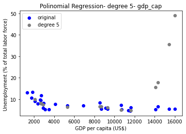

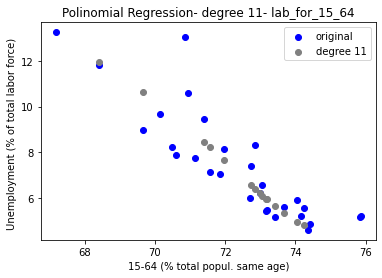

```python
# RegressionAndResults (X_best_feats[3], df_c[3], C[3], df_fields, 1)
```

```
Country: RUS

Regression ['gdp_cap']
Best score: -6.639959177625654 Cross validation 5
Degree: 1
Model: Pipeline(steps=[('polynomialfeatures', PolynomialFeatures(degree=1)),
                ('linearregression', LinearRegression())])
--------------------------
```

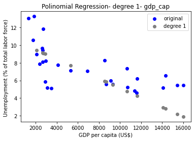

```python
# RegressionAndResults (df_c[3][['gdp_cap']], df_c[3], C[3], df_fields, (5,5))
```

```
Country: RUS

Regression ['exp_edu']
Best score: -0.936777864289927 Cross validation 14
Degree: 2
Model: Pipeline(steps=[('polynomialfeatures', PolynomialFeatures()),
                ('linearregression', LinearRegression(normalize=True))])
--------------------------
```

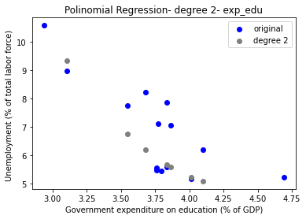

```python
# Choosing another feature
# RegressionAndResults (df_reg[df_reg['country']=='RUS'][['exp_edu']], df_reg[df_reg['country']=='RUS'], C[3], df_fields, 1)
```

```
Country: ZAF

Regression ['employers']
Best score: -2.8539237419016765 Cross validation 20
Degree: 1
Model: Pipeline(steps=[('polynomialfeatures', PolynomialFeatures(degree=1)),
                ('linearregression',
                 LinearRegression(fit_intercept=False, normalize=True))])
--------------------------
Country: ZAF

Regression ['gdp_cap']
Best score: -2.15707280201482 Cross validation 19
Degree: 1
Model: Pipeline(steps=[('polynomialfeatures', PolynomialFeatures(degree=1)),
                ('linearregression',
                 LinearRegression(fit_intercept=False, normalize=True))])
--------------------------
```

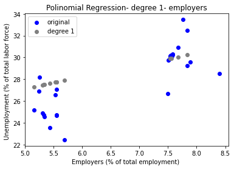

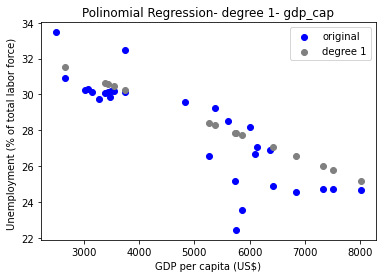

```python
# RegressionAndResults (X_best_feats[4], df_c[4], C[4], df_fields, 1)
```

## Conclusions

- GDP per capita is the most common feature correlated to unemployment among the countries.
- Other relevant common features are vulnerable unemployment, labour force participation rate, government expenditure and foreign direct investment and net inflows.
- Generally, when the unemployment increases, GDP per capita decreases. However, in China, unemployment and GDP per capita increase along the time. In Brazil, these 2 variables are not correlated.
- While in Brazil unemployment is related to the decrease in the industry (as a % of GDP), in China, is related to the decrease in agriculture. In both countries, when the unemployment rate increases, the percentage of services in GDP increases, too.
- In South Africa and Russia, the government expenditure (as a % of GDP) decreases when the unemployment rate growths whereas in Brazil and China it increases. For India, Russia and South Africa, the foreign direct investment and net inflows reduce as the unemployment rises. In contrast, in China this indicator increases.
- In China, when the unemployment increases, trading, the export and import of goods (as a % of GDP) increase too. Nevertheless, in South Africa the opposite is true: trading, export and import of goods decrease.
- In South Africa, the higher the unemployment rate, the lower the percentage of waged and salaried worker and the higher the percentage of vulnerable employment. In India, the unemployment rate increases as the vulnerable employment increases, as well. However, in China, the percent of waged and salaried worker increase as the unemployment rate increases.
- In China and Russia, the lower the labour force participating rate (labour force divided by the total working-age population), the higher the unemployment. In China labour force has been reducing along the years, whereas in Russia, since the beginning of the 2000s it has been increasing.
- In Russia, the unemployment rate is lower when the percentage of the urban population is higher.

#### Significance of the model

The model has a good result/accuracy for most analyses.

However, some regressions (mainly the second best features) did not represent the model in the best way:

1. The second graphic regression of India, "Unemployment x GDP per capita" was also less accurate.

Other graphics such as those in India and South Africa are more dispersed, consequently more complicated to be represented, but the results were relatively within expectations.

To improve these regressions may be necessary to test other methods. A study deeper is necessary, but maybe, for the solution of cases 1 and 2, can be interesting to use stratified sampling. Some classification problems can exhibit a large imbalance in the distribution of the target classes: for instance, there could be several times more high values x samples than low values samples. In such cases, it is recommended to use stratified sampling as implemented in StratifiedKFold and StratifiedShuffleSplit to ensure that relative class frequencies are approximately preserved in each train and validation fold.

#### Strength:

The model analyse several variables to find the solution, including the number of cross-validation, degrees and parameters.

#### Limitations:

The model was chosen based only on the values of mean squared error. No statistical tests were performed or other parameters were calculated to actually validate whether the model is coherent.

The model is a regression for only one variable, the possibility of multiple regression has not been analysed.

It is necessary to study more the choice of K in K-fold cross-validation.

However, if the learning curve is steep for the training size in question, then 5 or 10 fold cross validation can overestimate the generalization error(*).

In this project, sometimes high k values seemed better than k = 5 and k=10 due to the few points for certain values of x, and better than LOO because of less variance in relation to LOO, but it is suggested to deepen further the consequences of using high k values that are not LOO.

#### Performance

The performance of the regression model gets a little slow when iterating by a number of cross-validation. Mainly for high K values, e.g. k = N (leave one out method) because is computationally expensive. However, I prefer to keep this iteration to analyse the results and observe the results with different k.

Another part of the code with slow performance is the one that addresses the correlations between the indicators. The graphs of each country take an average of 3 minutes to be plotted. Even so, I preferred to keep them because it facilitates the quick extraction of visualizations between variables when necessary. However, a better solution can be adopted. One possibility is to plot graphs with indicators on the x-axis and only the variable unemployment on the y-axis.

- https://scikit-learn.org/stable/modules/cross_validation.html#cross-validation